# Applying A Reusable Plot Theme

# Goal

Reusable code is useful when you would otherwise copy and paste the same styling across many figures.

This notebook shows the basic reusable-theme move:

1. Make a basic graph.
2. Define one theme function.
3. Apply the function: `+ theme_name()`

# Load Data

```r
states <- readr::read_csv("data/real/state_population_ranks.csv")
countries <- readr::read_csv("data/real/infant_mortality_countries.csv")
```

# Prepare Data

| Data preparation step | Functions in this chunk |
| --- | --- |
| Keep or remove rows | `filter()` |
| Create or change columns | `mutate()` |

```r
top_states <- states |>
  filter(rank <= 15) |>
  mutate(state_name = reorder(state_name, population))

infant_mortality <- countries |>
  filter(!is.na(infant_mortality_per_1000))
```

# Basic Graph

Start with the plot. Do not worry about styling yet.

| Plot component | Code in this chunk |
| --- | --- |
| Aesthetic mappings | `x`; `y` |
| Geoms / stats | `geom_point()` |
| `geom_point()` properties | `alpha`; `size` |
| Scales / coordinates / facets / labels | `scale_x_log10()`; `labs()` |

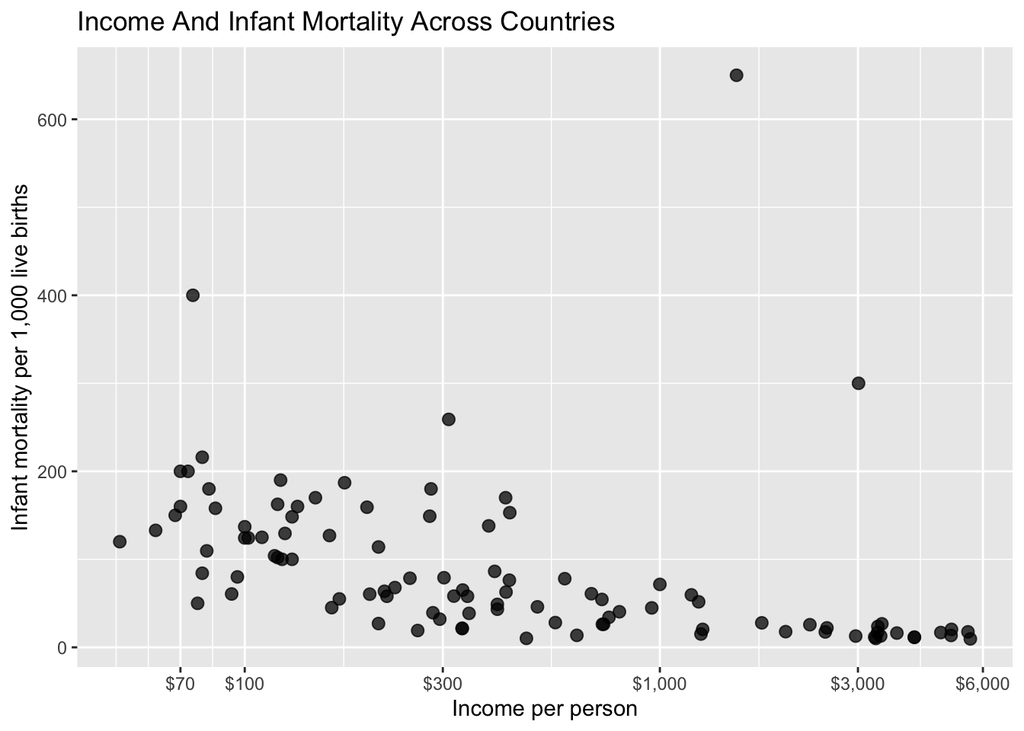

```r
p1 <- ggplot(
  infant_mortality,
  aes(x = income_usd_per_capita, y = infant_mortality_per_1000)
) +
  geom_point(alpha = 0.75, size = 2.5) +
  scale_x_log10(
    breaks = c(70, 100, 300, 1000, 3000, 6000),
    labels = c("$70", "$100", "$300", "$1,000", "$3,000", "$6,000")
  ) +
  labs(
    title = "Income And Infant Mortality Across Countries",
    x = "Income per person",
    y = "Infant mortality per 1,000 live births"
  )

p1
```

# One Reusable Theme

Now put the repeated styling into one function.

| Plot component | Code in this chunk |
| --- | --- |
| Scales / coordinates / facets / labels | `theme_minimal()`; `theme()` |

```r
theme_jhu <- function() {
  update_geom_defaults("bar", list(fill = "#002D72"))
  update_geom_defaults("point", list(color = "#002D72"))

  theme_minimal(base_family = "Tahoma") +
    theme(
      plot.title = element_text(
        family = "Georgia",
        size = 18,
        hjust = 0.5,
        face = "bold",
        margin = margin(b = 10)
      ),
      plot.subtitle = element_text(
        hjust = 0.5,
        family = "Tahoma",
        size = 12,
        margin = margin(t = 5, b = 15)
      ),
      plot.caption = element_text(
        family = "Tahoma",
        size = 10,
        color = "#7E7E7C",
        margin = margin(t = 15)
      ),
      axis.text.y = element_text(
        family = "Tahoma",
        size = 9,
        color = "#2C2C33"
      ),
      axis.text.x = element_text(
        family = "Tahoma",
        size = 9,
        color = "#2C2C33"
      ),
      axis.title.y = element_text(
        family = "Tahoma",
        size = 11,
        margin = margin(r = 15),
        face = "bold"
      ),
      axis.title.x = element_text(
        family = "Tahoma",
        size = 11,
        margin = margin(t = 15),
        face = "bold"
      ),
      axis.line.x = element_blank(),
      axis.line.y = element_blank(),
      panel.grid.major.x = element_line(
        color = "#E5E2E0",
        linewidth = 0.5,
        linetype = "solid"
      ),
      panel.grid.minor = element_blank()
    )
}
```

It’s often useful to save this function in a file you load at the top of every script/notebook or in a `bootstrap()` function.

# Apply The Theme

Add the theme to the plot.

| Plot component | Code in this chunk |
| --- | --- |
| Scales / coordinates / facets / labels | `theme_jhu()` |

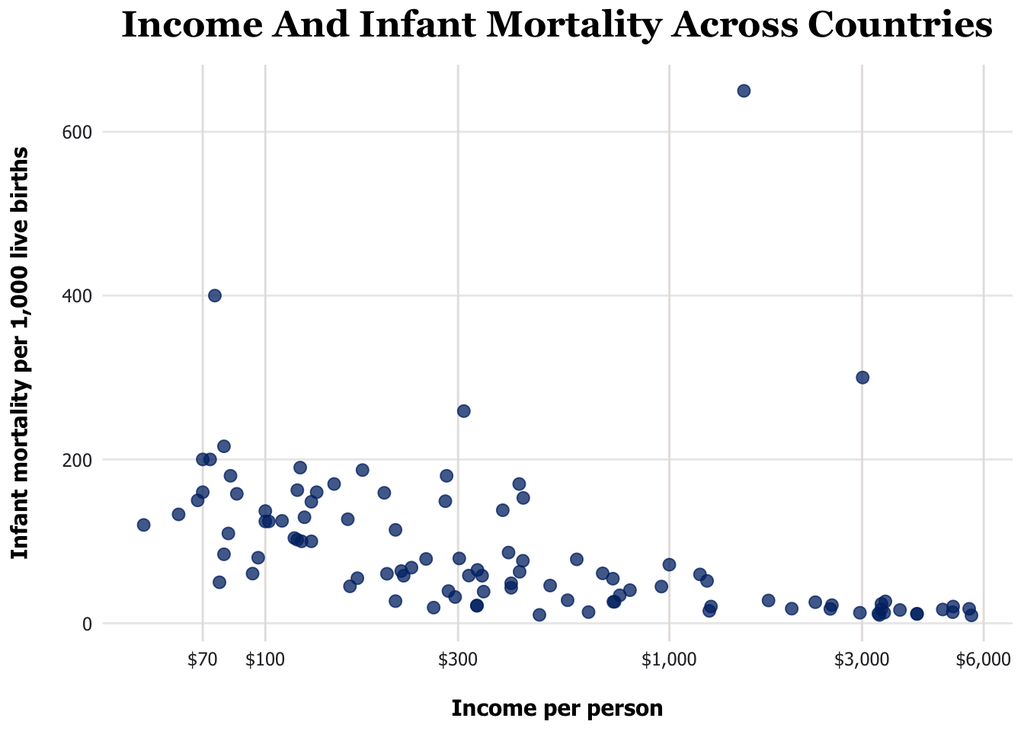

```r
p1 +
  theme_jhu()
```

Now you have a fully styled plot without an overwhelming amount of code.

# Apply The Same Theme To Another Plot

The value comes in consistent styling without repeating yourself. You can still override pieces for a specific plot.

| Plot component | Code in this chunk |
| --- | --- |
| Aesthetic mappings | `x`; `y` |
| Geoms / stats | `geom_bar()` |
| Scales / coordinates / facets / labels | `coord_flip()`; `scale_y_continuous()`; `labs()`; `theme_jhu()`; `theme()` |

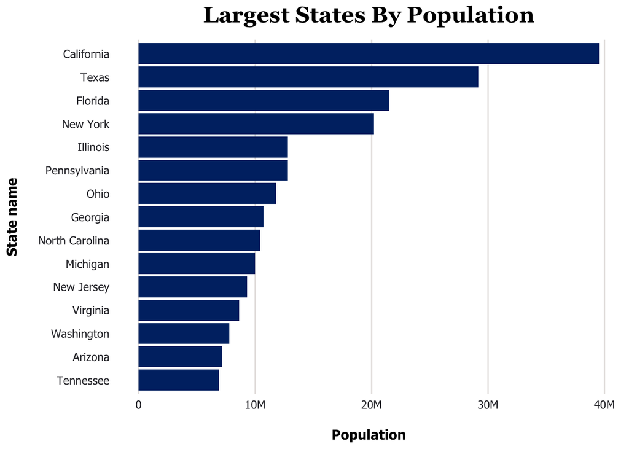

```r
p2 <- ggplot(top_states, aes(x = state_name, y = population)) +
  geom_bar(stat = "identity") +
  coord_flip() +
  scale_y_continuous(labels = scales::label_number(scale_cut = scales::cut_short_scale())) +
  labs(
    title = "Largest States By Population",
    x = "State name",
    y = "Population"
  )

p2 +
  theme_jhu() +
  theme(
    panel.grid.major.y = element_blank()
  )
```

# When to Extract

A good rule of thumb: extract a function the third time you repeat the same code.

# Takeaways

- A theme is just a function that includes a lot of styling boilerplate.
- Add it to a plot like you would any other ggplot2 feature. Here, we use `+ theme_jhu()`.
- Keep data choices in the plot code, not the theme function.